# Analiza Danych - Sprawozdanie 1

### Zadanie 2

Zweryfikuj empirycznie (np. za pomocą wykresu gęstości), że rozkład wykładniczy z parametrem $\lambda$ jest szczególnym przypadkiem rozkładu Gamma z parametrami $\lambda$ i $k=1$.

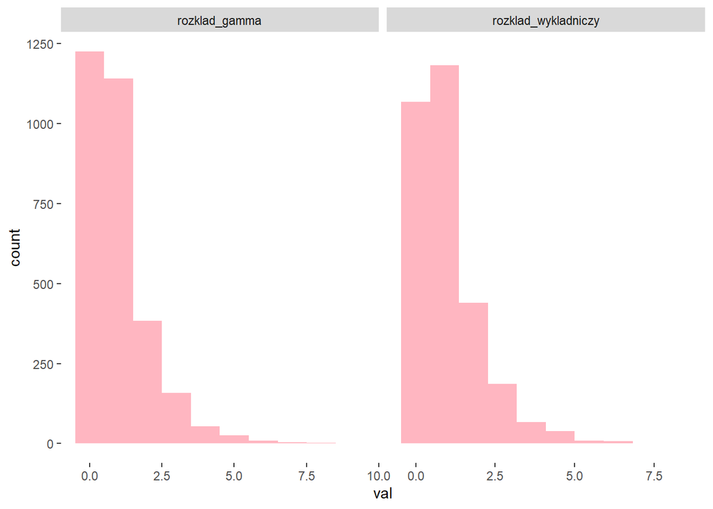

```r
set.seed(3141529)
lambda <- 1
comp_tibble <- tibble(rozklad_wykladniczy = rexp(n=3000, rate=lambda),
                      rozklad_gamma = rgamma(n=3000, shape=1, rate=lambda))
comp_tibble_piv <- comp_tibble %>% pivot_longer(1:2, names_to = "dist", values_to = "val")
ggplot(comp_tibble_piv, aes(x=val)) + geom_histogram(bins = 10, fill = "lightpink") +
  facet_grid(~dist, scales = "free") +
  theme(panel.background = element_blank())
```

Powyższe wykresy są bardzo podobne do siebie, co sugeruje, że rozkład wykładniczy z parametrem $\lambda$ może być szczególnym przypadkiem rozkładu Gamma z parametrami $\lambda$ i $k=1$.

Sprawdzimy to obliczeniami:

Dla $k=1$ gęstość rozkładu Gamma jest równa:
$$f(x) =
\frac{\lambda^1}{\Gamma(1)} x^{1-1}e^{-\lambda x}, \, \rm{dla}\, x \in
(0, \infty).$$
Po przekształceniach otrzymujemy:
$$f(x) = \lambda e^{-\lambda x}, \, \rm{dla}\, x
\in (0, \infty),$$
co jest równe gęstości rozkładu wykładniczego.

### Zadanie 3

Zweryfikuj empirycznie (np. za pomocą wykresów gęstości), że suma $k$ niezależnych zmiennych o rozkładzie wykładniczym z tym samym parametrem $\lambda$ ma rozkład Gamma z parametrami $\lambda$, $k$.

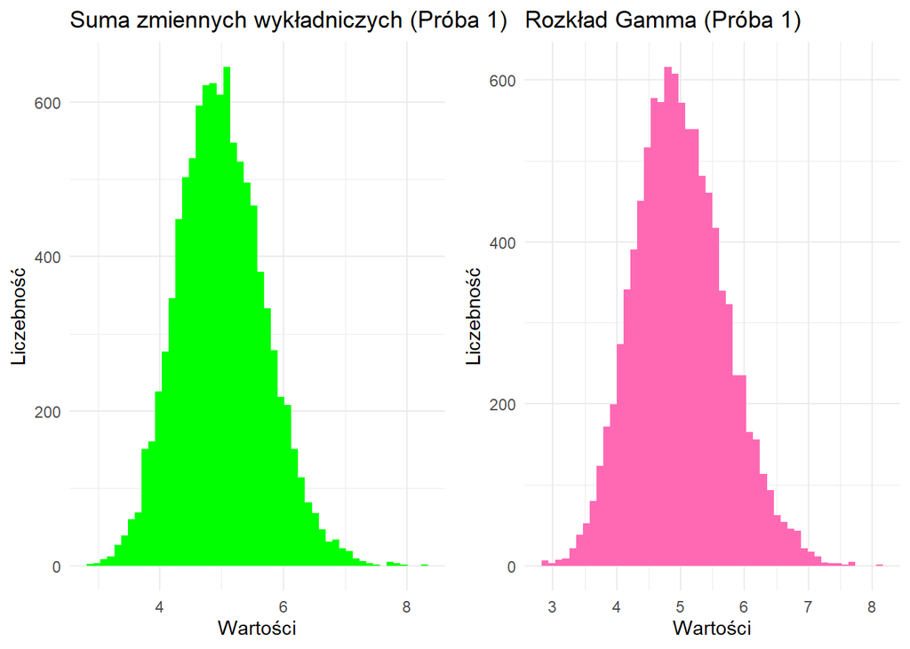

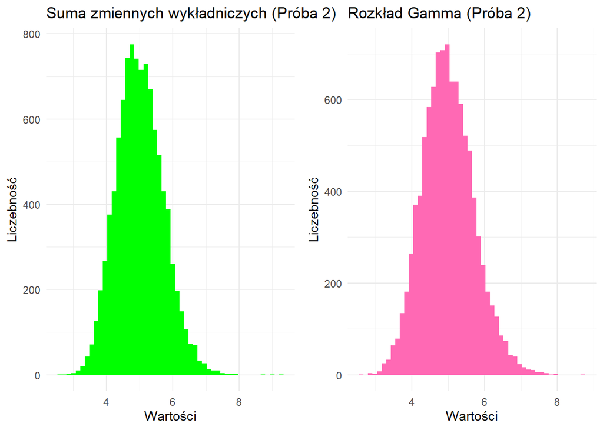

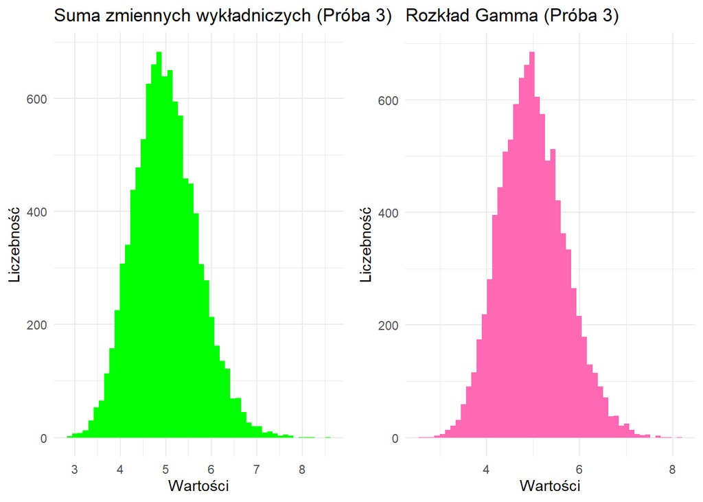

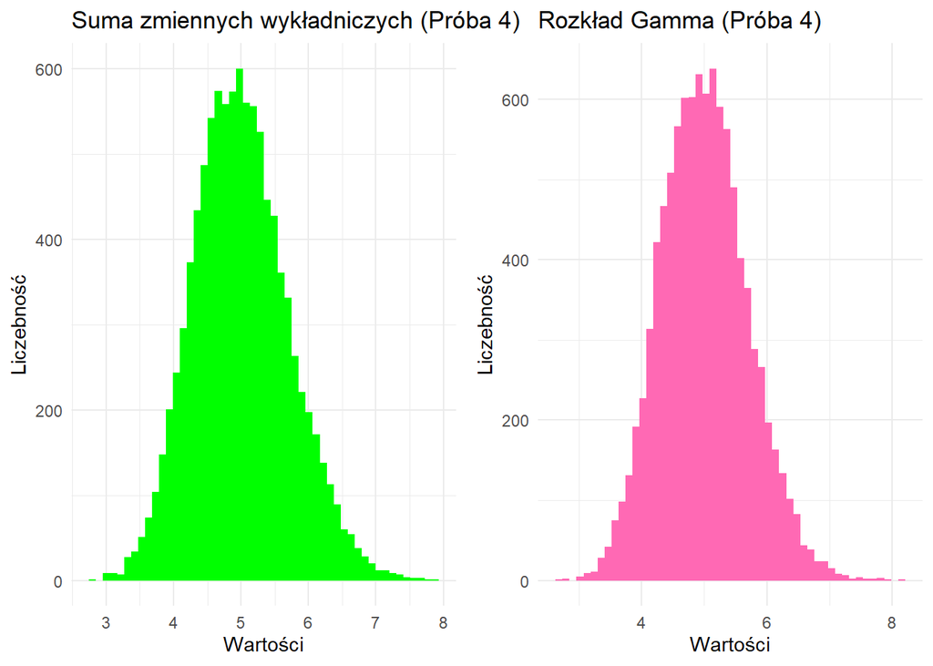

```r
lambda <- 10
k <- 50
n <- 10000
liczba_prob <- 4

for (i in 1:liczba_prob) {
  set.seed(314 + i)

  suma <- numeric(n)
  for (j in 1:k) {
    suma <- suma + rexp(n, rate = lambda)
  }
  suma1 <- as_tibble(suma)

  probka <- rgamma(n, shape = k, rate = lambda)
  probka1 <- as_tibble(probka)

  wykres1 <- ggplot(suma1, aes(x = suma)) +
    geom_histogram(fill = "green", bins = 50) +
    labs(title = paste0("Suma zmiennych wykładniczych (Próba ", i, ")"),
         x = "Wartości", y = "Liczebność") +
    theme_minimal()


  wykres2 <- ggplot(probka1, aes(x = probka)) +
    geom_histogram(fill = "hotpink", bins = 50) +
    labs(title = paste0("Rozkład Gamma (Próba ", i, ")"),
         x = "Wartości", y = "Liczebność") +
    theme_minimal()

  print(ggarrange(wykres1, wykres2, ncol = 2, nrow = 1))
}
```

Powyższe wykresy są do siebie bardzo podobne. Na wszystkich obrazkach na obydwu histogramach można zauważyć, że najwięcej wartości przyjmowanych jest dla liczby 5, czyli średnia wynosi około 5. Oprócz tego, są stosunkowo strome i można powiedzieć, że symetryczne, pomimo tego, że mają odrobinę dłuższe prawe ogony. Empiryczny histogram sumy rozkładów wykładniczych jest oszacowaniem teoretycznej gęstości rozkładu Gamma, co oznacza, że suma $k$ niezależnych zmiennych o rozkładzie wykładniczym z tym samym parametrem $\lambda$ może mieć rozkład Gamma z parametrami $\lambda$, $k$.